# WinMoreValo

Chananan Srasri

2022-05-22

# 1. Introduction

Valorant is first person shooter compettitive game that’s currently hottest game in this game type beside CS:GO. I myself have play this game together with my group of friends and beginning to doubt why we’re struggle to rank up. So I decide to find what factor will lead our squad to victory.

# 2. Obtain

The data I will use to perform this analysis was obtained from [this](https://www.kaggle.com/datasets/visualize25/valorant-pro-matches-full-data) Kaggle dataset which was obtained via vlr.gg. It includes data from Valorant’s pro match up to Jan 1,2022. This dataset was come in SQLite type, included 4 tables in it like Game_Rounds, Game_Scoreboard, Games, Matches. But this analysis is just base on Games table because it’s represent my interested fields.

## 2.1 Glossary of Features:

- TotalRound: Total win round of observing team. Normally it’s equal 13 round (Game’s winning condition is for which team reach 13 round win first will win the match).
- SideFirstHalf: Valorant is compettitive game, so it must altered between attack and defense team.
- RoundOT: The overtime round, If 2 teams have 12 wins equally, they must win 2 rounds in row to win the match.
- RoundFirstHalf/ SecondHalf: There are 12 round each half for defending or attacking.
- Pistol: Normally it’s the first round of each side. Each team will start with free pistol or can buy some pistol of choice. In my perspective, the pistol round will determine which team will win the match.
- Eco: Means Economy round. If your team fall behind in economy some leader in the team will call for economy round. They will have to save **all** of money to buy bigger guns in the next round (Full buy) for more impact round.
- SemiEco: Similar to Eco but they just buy some abilities and smaller pistol to increase winning chance.
- SemiBuy: In this round, players can buy some medium gun and abilities. But they aren’t much effective as the rifles or heavier gun in FullBuy round. - FullBuy: Buy the best gun and every ability you want to maximize winning chance!

```r
# Connect R to database
library(RSQLite)

# 1. Connect DB
conn <- dbConnect(SQLite(), "data/valorant.sqlite")

# 2. List Table
dbListTables(conn)
```

```
## [1] "Game_Rounds"     "Game_Scoreboard" "Games"           "Matches"
```

```r
# 3. List Fields
dbListFields(conn, "Games")
```

```
##  [1] "GameID"                  "MatchID"
##  [3] "Map"                     "Team1ID"
##  [5] "Team2ID"                 "Team1"
##  [7] "Team2"                   "Winner"
##  [9] "Team1_TotalRounds"       "Team2_TotalRounds"
## [11] "Team1_SideFirstHalf"     "Team2_SideFirstHalf"
## [13] "Team1_RoundsFirstHalf"   "Team1_RoundsSecondtHalf"
## [15] "Team1_RoundsOT"          "Team2_RoundsFirstHalf"
## [17] "Team2_RoundsSecondtHalf" "Team2_RoundsOT"
## [19] "Team1_PistolWon"         "Team1_Eco"
## [21] "Team1_EcoWon"            "Team1_SemiEco"
## [23] "Team1_SemiEcoWon"        "Team1_SemiBuy"
## [25] "Team1_SemiBuyWon"        "Team1_FullBuy"
## [27] "Team1_FullBuyWon"        "Team2_PistolWon"
## [29] "Team2_Eco"               "Team2_EcoWon"
## [31] "Team2_SemiEco"           "Team2_SemiEcoWon"
## [33] "Team2_SemiBuy"           "Team2_SemiBuyWon"
## [35] "Team2_FullBuy"           "Team2_FullBuyWon"
```

```r
# 4. Query data
Games <- dbGetQuery(conn, "SELECT *
                    FROM Games LIMIT 1001")
dbDisconnect(conn)
```

# 3. Clean

## 3.1 Data Preparation

```r
#  load tidyverse library and caret for data transformation and machine learning in advance
library(tidyverse)
library(caret)
library(ranger)
library(caTools) #for logistic regression

# find total NA values
summary(Games)
```

```
##     GameID            MatchID              Map               Team1ID
##  Length:1001        Length:1001        Length:1001        Min.   :   2
##  Class :character   Class :character   Class :character   1st Qu.:2059
##  Mode  :character   Mode  :character   Mode  :character   Median :4940
##                                                           Mean   :4253
##                                                           3rd Qu.:6387
##                                                           Max.   :7047
##
##     Team2ID        Team1              Team2              Winner
##  Min.   :   2   Length:1001        Length:1001        Length:1001
##  1st Qu.:2917   Class :character   Class :character   Class :character
##  Median :5832   Mode  :character   Mode  :character   Mode  :character
##  Mean   :4788
##  3rd Qu.:6478
##  Max.   :7047
##
##  Team1_TotalRounds Team2_TotalRounds Team1_SideFirstHalf Team2_SideFirstHalf
##  Min.   : 1.00     Min.   : 0.000    Length:1001         Length:1001
##  1st Qu.:13.00     1st Qu.: 5.000    Class :character    Class :character
##  Median :13.00     Median : 9.000    Mode  :character    Mode  :character
##  Mean   :12.05     Mean   : 8.497
##  3rd Qu.:13.00     3rd Qu.:12.000
##  Max.   :18.00     Max.   :17.000
##
##  Team1_RoundsFirstHalf Team1_RoundsSecondtHalf Team1_RoundsOT
##  Min.   : 0.000        Min.   : 0.000          Min.   :0.0000
##  1st Qu.: 5.000        1st Qu.: 3.000          1st Qu.:0.0000
##  Median : 7.000        Median : 5.000          Median :0.0000
##  Mean   : 7.108        Mean   : 4.744          Mean   :0.1858
##  3rd Qu.: 9.000        3rd Qu.: 6.000          3rd Qu.:0.0000
##  Max.   :12.000        Max.   :11.000          Max.   :6.0000
##
##  Team2_RoundsFirstHalf Team2_RoundsSecondtHalf Team2_RoundsOT   Team1_PistolWon
##  Min.   : 0.00         Min.   : 0.000          Min.   :0.0000   Min.   :0.000
##  1st Qu.: 3.00         1st Qu.: 1.000          1st Qu.:0.0000   1st Qu.:1.000
##  Median : 5.00         Median : 3.000          Median :0.0000   Median :1.000
##  Mean   : 4.88         Mean   : 3.505          Mean   :0.1009   Mean   :1.192
##  3rd Qu.: 7.00         3rd Qu.: 5.000          3rd Qu.:0.0000   3rd Qu.:2.000
##  Max.   :11.00         Max.   :10.000          Max.   :5.0000   Max.   :2.000
##                                                                 NA's   :1
```

[output cut: 25 more lines]

```
##  Min.   :0.000    Min.   : 0.000   Min.   :0.000    Min.   : 3.00
##  1st Qu.:0.000    1st Qu.: 3.000   1st Qu.:1.000    1st Qu.: 8.00
##  Median :0.000    Median : 4.000   Median :2.000    Median :11.00
##  Mean   :0.254    Mean   : 4.548   Mean   :1.968    Mean   :11.01
##  3rd Qu.:0.000    3rd Qu.: 6.000   3rd Qu.:3.000    3rd Qu.:14.00
##  Max.   :3.000    Max.   :11.000   Max.   :6.000    Max.   :25.00
##  NA's   :1        NA's   :1        NA's   :1        NA's   :1
##  Team2_FullBuyWon
##  Min.   : 0.000
##  1st Qu.: 3.000
##  Median : 5.000
##  Mean   : 5.385
##  3rd Qu.: 8.000
##  Max.   :13.000
##  NA's   :1
```

```r
sum(is.na(Games))
```

```
## [1] 18
```

```r
# delete NA row and re-select data from 1000 rows to 1001 rows
Games <- na.omit(Games)

# check Column name
names(Games)
```

```
##  [1] "GameID"                  "MatchID"
##  [3] "Map"                     "Team1ID"
##  [5] "Team2ID"                 "Team1"
##  [7] "Team2"                   "Winner"
##  [9] "Team1_TotalRounds"       "Team2_TotalRounds"
## [11] "Team1_SideFirstHalf"     "Team2_SideFirstHalf"
## [13] "Team1_RoundsFirstHalf"   "Team1_RoundsSecondtHalf"
## [15] "Team1_RoundsOT"          "Team2_RoundsFirstHalf"
## [17] "Team2_RoundsSecondtHalf" "Team2_RoundsOT"
## [19] "Team1_PistolWon"         "Team1_Eco"
## [21] "Team1_EcoWon"            "Team1_SemiEco"
## [23] "Team1_SemiEcoWon"        "Team1_SemiBuy"
## [25] "Team1_SemiBuyWon"        "Team1_FullBuy"
## [27] "Team1_FullBuyWon"        "Team2_PistolWon"
## [29] "Team2_Eco"               "Team2_EcoWon"
## [31] "Team2_SemiEco"           "Team2_SemiEcoWon"
## [33] "Team2_SemiBuy"           "Team2_SemiBuyWon"
## [35] "Team2_FullBuy"           "Team2_FullBuyWon"
```

```r
  ## since I want to see Team 1 winning conditions so I cut other non Team 1 related column
tGames <- Games %>%
  select(Map, Team1, Team2, Winner, starts_with("Team1_")) %>%
  mutate(Team1_Win = if_else(Team1 == Winner, 1, 0),
         Team1_Attack = if_else(Team1_SideFirstHalf == "attack", 1, 0))
         # create 2 new column and change Team1_win into factor

  ## select the working data
tGames2 <- tGames %>%
  select(starts_with("Team1_"), -Team1_SideFirstHalf)
```

# 4. Data Exploration

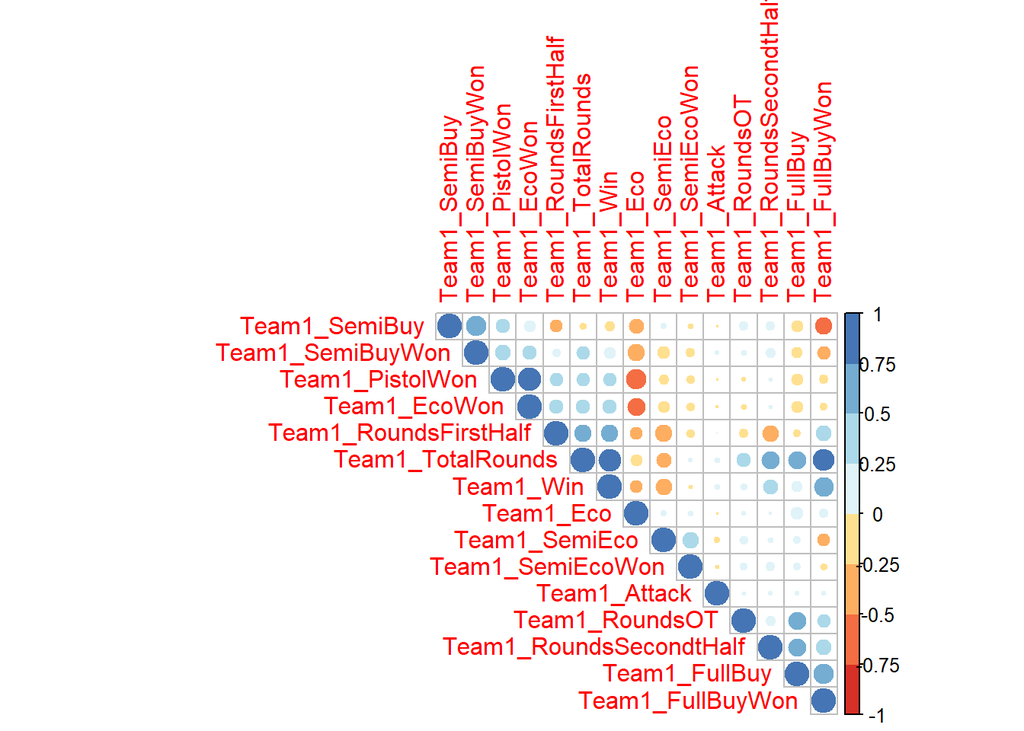

```r
# visulize data to see more correlated value with correlation matrix
library(corrplot) #correlation plot matrix
library(RColorBrewer)
M <- cor(tGames2)
corrplot(M, type="upper", order="hclust",
         col=brewer.pal(n=8, name="RdYlBu"))
```

```r
# explore data
library(explore) # library for exploring
# explore(tGames2) # interactive data can't run on R mark down
```

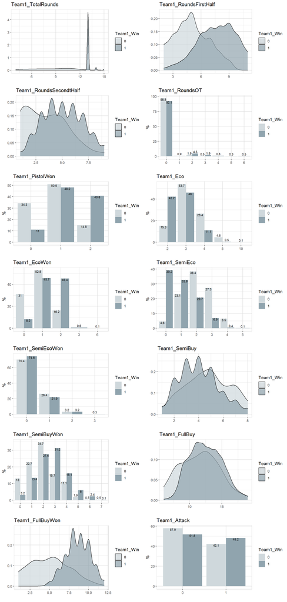

As we can see from correlation plot matrix and explored variables. The FullBuy play the most important roles for winning more. On the other hand, the more you do semi-buy round the more likelihood to lose.

# 5. Model

Now we have seen that there is some relationship between the winning chance and other buy rounds, I want to dive deeper to create a model that can predicts the outcome of a match.

I will use four model types 1. Logistic regression 2.Classification and regression trees (CART) 3. K-Nearest Neighbor (KNN) 4. Random forest (ranger).

I’m going to change column type to factor for using in model.

```r
## change column type from numeric to factor
tGames2 <- tGames2 %>%
  select(starts_with("Team1_")) %>%
  mutate(Team1_Win = as.factor(Team1_Win),
         Team1_Attack = as.factor(Team1_Attack))
    # create 2 new columns and change their type to factor
```

Then, it’s time for modeling.

```r
# split data for training and testing
set.seed(11)
id <- createDataPartition(tGames2$Team1_Win, p = 0.8, list = F)

train_data <- tGames2[id, ] #train80%
test_data <- tGames2[-id, ] #test20%

#set train control to k-fold cv
set.seed(11)
ctrl <- trainControl(method = "cv",
                     number = 5,
                     verboseIter = TRUE)

# build models
    ## Logistic
set.seed(11)
logit_model <- train(Team1_Win~.,
                   data = train_data,
                   method = "LogitBoost",
                   metric = "Accuracy",
                   trControl = ctrl)
    ##CART
set.seed(11)
cart_model <- train(Team1_Win~.,
                     data = train_data,
                     method = "rpart",
                     metric = "Accuracy",
                     trControl = ctrl)
    ##knn
set.seed(11)
knn_model <- train(Team1_Win~.,
                     data = train_data,
                     method = "knn",
                     metric = "Accuracy",
                     trControl = ctrl)
    ## Randomforest
set.seed(11)
ranger_model <- train(Team1_Win~.,
                     data = train_data,
                     method = "ranger",
                     metric = "Accuracy",
                     trControl = ctrl)
```

Overall, the model is completed. But which model is the best to predict the winning team?

```r
# select best model
  ## summarise accuracy of models
results <- resamples(list(logit = logit_model,
                          cart = cart_model,
                          knn = knn_model,
                          ranger = ranger_model))
summary(results)
```

```
##
## Call:
## summary.resamples(object = results)
##
## Models: logit, cart, knn, ranger
## Number of resamples: 5
##
## Accuracy
##           Min. 1st Qu.    Median      Mean   3rd Qu.    Max. NA's
## logit  0.98125 0.99375 0.9937500 0.9925078 0.9937888 1.00000    0
## cart   0.98125 0.99375 0.9937888 0.9937578 1.0000000 1.00000    0
## knn    0.96250 0.96875 0.9689441 0.9712888 0.9750000 0.98125    0
## ranger 0.98125 0.99375 0.9937888 0.9937578 1.0000000 1.00000    0
##
## Kappa
##             Min.   1st Qu.    Median      Mean   3rd Qu.      Max. NA's
## logit  0.9433962 0.9811232 0.9815557 0.9775951 0.9819005 1.0000000    0
## cart   0.9433962 0.9811232 0.9815557 0.9812150 1.0000000 1.0000000    0
## knn    0.8802395 0.9036145 0.9037657 0.9106903 0.9237187 0.9421129    0
## ranger 0.9433962 0.9811232 0.9815557 0.9812150 1.0000000 1.0000000    0
```

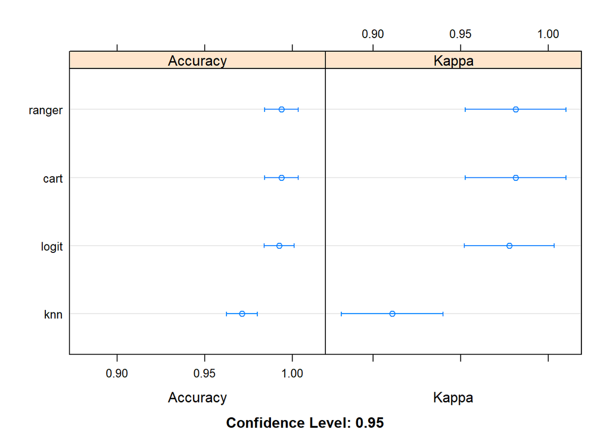

```r
  ## compare accuracy of models
dotplot(results)
```

```r
  ## summarise bets model
print(ranger_model)
```

```
## Random Forest
##
## 801 samples
##  14 predictor
##   2 classes: '0', '1'
##
## No pre-processing
## Resampling: Cross-Validated (5 fold)
## Summary of sample sizes: 641, 640, 641, 641, 641
## Resampling results across tuning parameters:
##
##   mtry  splitrule   Accuracy   Kappa
##    2    gini        0.9937578  0.9812150
##    2    extratrees  0.9750311  0.9229447
##    8    gini        0.9937578  0.9812150
##    8    extratrees  0.9925078  0.9773568
##   14    gini        0.9925078  0.9775207
##   14    extratrees  0.9937578  0.9812150
##
## Tuning parameter 'min.node.size' was held constant at a value of 1
## Accuracy was used to select the optimal model using the largest value.
## The final values used for the model were mtry = 2, splitrule = gini
##  and min.node.size = 1.
```

```r
# score and evaluate
p <- predict(ranger_model, test_data)
cmatrix <- confusionMatrix(p, test_data$Team1_Win)

print(cmatrix)
```

```
## Confusion Matrix and Statistics
##
##           Reference
## Prediction   0   1
##          0  41   0
##          1   2 156
##
##                Accuracy : 0.9899
##                  95% CI : (0.9642, 0.9988)
##     No Information Rate : 0.7839
##     P-Value [Acc > NIR] : <2e-16
##
##                   Kappa : 0.9698
##
##  Mcnemar's Test P-Value : 0.4795
##
##             Sensitivity : 0.9535
##             Specificity : 1.0000
##          Pos Pred Value : 1.0000
##          Neg Pred Value : 0.9873
##              Prevalence : 0.2161
##          Detection Rate : 0.2060
##    Detection Prevalence : 0.2060
##       Balanced Accuracy : 0.9767
##
##        'Positive' Class : 0
##
```

# 6. Conclusion

Based on the above findings we can see that Fullbuy round play the most important roles for winning. I assume that the more fullbuy round will lead to less eco rounds and less eco rounds means you lose less either.

So, if you want to win more you should focus in economy in game for more fullbuy round. That’s all I can extract from this analysis.

## 6.1 Further recommedations for this analysis

This is my first real life problem project for me as a beginner data scientist. But my thought to my project is I can squeeze some more meaningful insight if I became better at this. Such as, I want to change the Eco round and Eco win to be Eco_Win_Percentage. But when I tried it there was some error that occurred and the NA values are coming when my divider data was 0 and I can’t do anything to it.

Furthermore, My Machine learning of choice maybe not that good. Might be from the lack of knowledge and experience.